# Plot changes in flow, sediment, DOC, and NO3 across fire severity/burned area scenarios

PR

2023-04-19

## Intro and scope:

Since there are issues with the original code I wrote, I’m going to rewrite in RMD form so it’ll be easier to explain what I’m doing and diagnose where things are going wrong. The goal is to take the output files from modeling and plot how different scenarios impact water quantity (flow) and quality (concentrations of sediments, NO3, and DOC). There are two scenario types: fire characteristics (manipulate fire intensity/burn extent) and watershed characteristics (manipulate watershed slope / flows / vegetation). Currently, fire characteristics are available for the “New” model, so will plot those, then add in watershed characteristics once model outputs are uploaded. **NOTE: need to change the email (L38) to authorize `googledrive` to download raw data.**

```
## logical(0)
```

## Workflow

```
## # A tibble: 37 × 7
##    scenario      severity perc_burned  flow   sed nitrate_mgL doc_mgL
##    <chr>         <chr>    <chr>       <dbl> <dbl>       <dbl>   <dbl>
##  1 PER_100_MOD   MOD      100          9.60  197.       0.703   2.56
##  2 base_unburned MOD      100          8.17  136.       0.359   0.468
##  3 PER_60_MOD    MOD      60           8.91  161.       0.464   1.11
##  4 PER_75_MOD    MOD      75           9.06  165.       0.497   1.16
##  5 PER_25_MOD    MOD      25           8.50  147.       0.415   0.942
##  6 PER_10_LOW    LOW      10           8.19  137.       0.372   0.691
##  7 PER_90_HIGH   HIGH     90          10.1   201.       0.682   1.43
##  8 PER_50_HIGH   HIGH     50           9.18  168.       0.490   1.02
##  9 PER_30_LOW    LOW      30           8.22  139.       0.381   0.699
## 10 PER_50_LOW    LOW      50           8.27  141.       0.382   0.732
## # … with 27 more rows
```

## Plotting

Time to make some plots. I’m suspecting, since this is mostly code from the first plot which made sense, that there is/was some mismatch between the Old Model files and my `230410_summarize_and_plot_scenarios.R` code. The test will be if scenarios for watershed characteristics make sense. This code does add in a check that the `base_unburned` rows match across all scnearios for columns they should match for, which is a good check, and one that won’t do much for watershed characteristics.

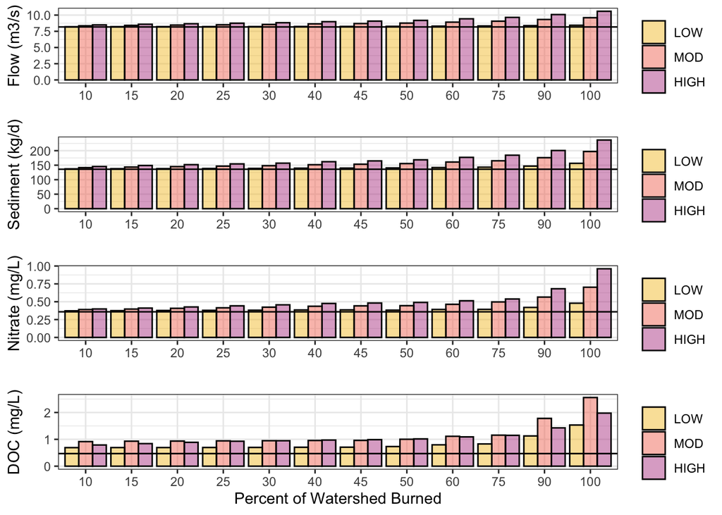